# Berapa Banyak Tes?

ikanx

7/6/2020

Kayaknya hampir semua orang kaget saat mendengar kabar bahwa [pabrik Unilever di Cikarang](https://www.cnnindonesia.com/nasional/20200703141857-20-520535/36-positif-corona-dari-klaster-unilever-bekasi-bupati-gusar) sudah ada 36 orang karyawan yang terpapar Covid 19. Tentunya ini adalah pukulan bagi perusahaan tersebut.

Hal serupa juga hantu yang membayangi setiap perusahaan manufaktur. Jika saja ada satu orang karyawan yang positif, bisa jadi merembet ke mana-mana.

Beberapa hari yang lalu, HP saya berdering. Teman saya di ujung telepon bertanya:

> Di pabrik saya ada sekitar 2.000 orang, kira-kira saya butuh ngetes berapa banyak orang karyawan agar bisa mendapatkan gambaran kondisi di perusahaan saya aman atau tidak?

*Mmh*, mendengar pertanyaan dari teman saya tersebut saya coba berpikir sejenak. Apa tujuan sebenarnya dari tes ini? Lalu apa yang akan dilakukan saat mendapati karyawan yang positif Covid 19?

Setidaknya ada beberapa cara yang saya pikir bisa untuk membantu teman saya ini.

## Cara pertama

Cara termudah untuk menyelesaikan masalah teman saya ini adalah dengan menghitung *sample size* seperti tim market riset menghitung berapa banyak responden yang representatif terhadap populasi.

Caranya simpel yah, kita bisa menggunakan *sample size calculator online* seperti milik [raosoft](http://www.raosoft.com/samplesize.html) ini. Jika menggunakan cara ini, setidaknya kita membutuhkan tiga informasi, yakni:

1. N, berapa banyak populasi.
2. *Margin of error*.
3. *Confidence level*.

Penjelasan mengenai *margin of error* dan *confidence level* sudah pernah saya tulis di [sini](https://passingthroughresearcher.wordpress.com/2019/04/18/research-101-mengenal-margin-of-error-dan-confidence-level/).

Sebagai contoh, saat kita memasukkan `N = 200`, `MoE = 5%`, dan `CL = 95%`, maka kita mendapatkan *sample size* yang harus diambil sebanyak 132 orang.

[figure not shown]

Lalu apakah masalah teman saya ini selesai dengan cara seperti ini?

Saya merasa ini belum selesai! Kenapa?

Saya coba kisahkan dalam analogi berikut ini yah:

> Misal, di komplek perumahan saya tinggal 200 orang. Saya penasaran, apakah ada orang dari suku Betawi yang hidup bersama saya di komplek ini. Setelah dihitung, saya harus mewawancarai 132 orang. Nah, misalkan saya hendak bertanya ke 132 orang secara acak. Bisa jadi pada saat saya bertanya ke orang pertama saya sudah mendapatkan orang Betawi. Bisa jadi saya baru mendapatkan orang Betawi pada saat bertanya ke orang ke-90. Bisa jadi pada saat orang ke-130.

Lalu pertanyaannya, apakah kita bisa menghitung peluang kita mendapatkan orang Betawi pada saat orang ke berapa? Apakah mungkin kita menghitung *sample size* lebih efisien lagi?

Nah, di sini saya mencoba menghitungnya dengan menggunakan simulasi Monte Carlo. Jadi utk melakukan simulasinya, saya cuma butuh 2 hal:

1. N populasi,
2. Dugaan berapa banyak orang betawi yang ada di komplek saya.

Jadi misalkan, saya menduga bahwa ada 10 orang betawi di komplek saya, maka:

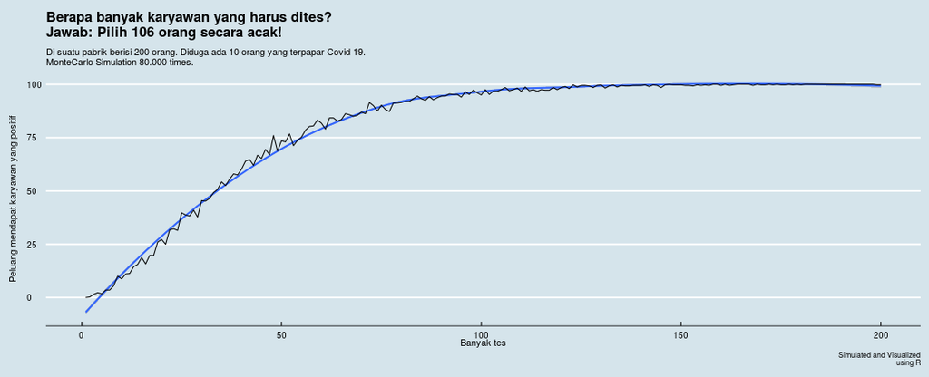

Jadi saat saya mewawancarai 106 orang secara acak, saya berpeluang besar sudah mendapatkan setidaknya satu orang betawi.

Bahkan saat saya mewawancari 50 orang saja, saya mendapatkan peluang 60% - 75% saya sudah mendapatkan orang betawi.

Cara kedua ini lebih saya pilih untuk kasus teman saya. Kenapa? Karena tujuan tes ini untuk mengamankan pabriknya dari Covid 19.

Simulasinya saya taruh di [shinyapps Covid 19](https://ikanx.shinyapps.io/covid_19/) saya ya. *Feel free to use it*.